# Homologação do layout da funcionalidade

# Visão geral da demanda

(inicio)

Essa demanda visa anonimizar dados pessoais, como por exemplo nomes e CPFs, de credores pessoas físicas nas consultas de Despesa e Restos a Pagar (RP) a partir de combinações especificas das classificações da dotação orçamentária, inclusive de anos de exercício e períodos de datas especificas, podendo definir até quais faixas de empenhos serão anonimizados.

Nota 1: No banco de dados do Portal da Transparência as informações de nome e CPF devem ser armazenadas sem anonimização/descaracterização, permitindo filtros que utilizem essas informações.

**Despesa**

Ao pesquisar um dado anonimizado (Nome ou CPF) no campo de busca do Portal o comportamento foi o esperado.

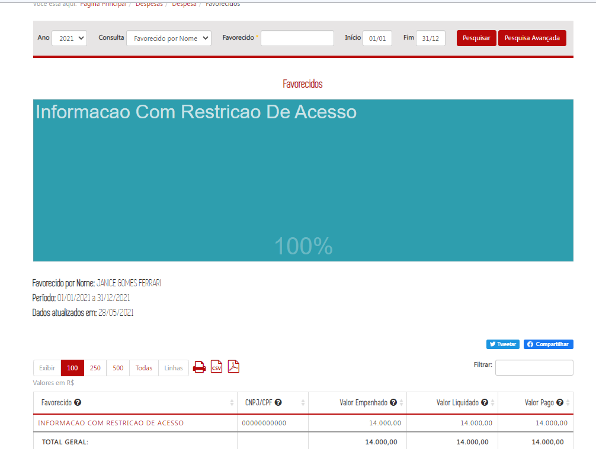

__

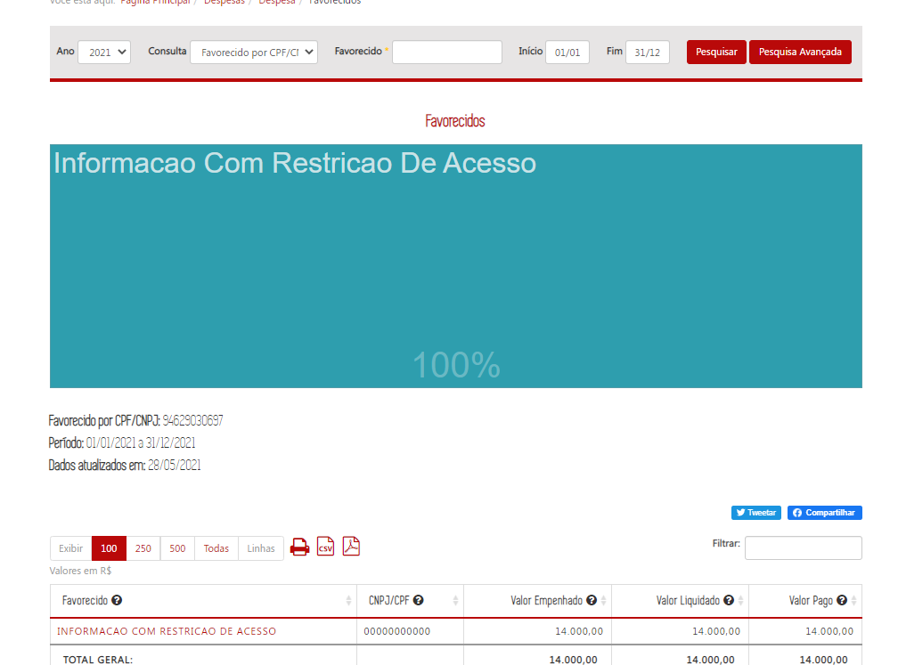

Nota 2: A solução deve ser flexível para que as combinações possam ser alteradas mediante provocação da CGE.

# Especificação

(inicio)

## Método de anonimização

A anonimização deve ser aplicada nas informações de nomes, CPFs e histórico de empenho das consultas de Despesa e Restos a Pagar do Portal de Transparência. As combinações de classificação, ano, período, número do empenho e outros campos devem contemplar todas as possibilidades de cruzamento.

Abaixo segue a lista dos campos que poderão ser combinados para aplicação da funcionalidade:

- Ano de exercício
- Período de datas (data de registro do empenho)
- Unidade Orçamentária
- Unidade Executora
- Função
- Subfunção
- Programa
- Ação
- Identificador de Procedência e Uso
- Categoria Econômica
- Grupo de Despesa
- Elemento de Despesa
- Item de Despesa
- Fonte de Recurso
- Modalidade de Aplicação
- Número do Empenho
- Unidade de Programação de Gasto

A regra de anonimização deve permitir tanto a aplicação inicial quanto o reprocessamento, ou seja, a DTA pode definir a partir de qual período a anonimização será aplicada, como também pode solicitar apenas um período especifico.

O método de anonimização consiste em:

- Quando se tratar de dados na consulta básica e formulário de detalhamento:
1. Substituir o nome do credor pelo valor “INFORMAÇÃO COM RESTRIÇÃO DE ACESSO”; e
2. Substituir o CPF do credor pelo valor “000.000.000-00”.

**Despesa**

[figure not shown]

As regras acima devem ser aplicadas inclusive no caso em que o nome e CPF sejam apresentados no mesmo campo, como nos formulários de detalhamento.

- Quando se tratar do campo histórico do empenho:
1. Substituir o nome do credor pelo valor “INFORMAÇÃO COM RESTRIÇÃO DE ACESSO” quando for possível identificar essa informação dentro do campo;
2. Substituir o CPF do credor pelo valor “000.000.000-00” quando for possível identificar essa informação dentro do campo
3. Caso **não seja possível** a identificação dos dados acima por se tratar de um campo aberto, a solução deverá ocultar toda a informação dentro do campo e o texto deverá ser substituído por “INFORMAÇÃO COM RESTRIÇÃO DE ACESSO” .

Como default sempre que for solicitado a anonimização dos dados de um determinado empenho o seu respectivo histórico deve ser anonimizado.

**Despesa**

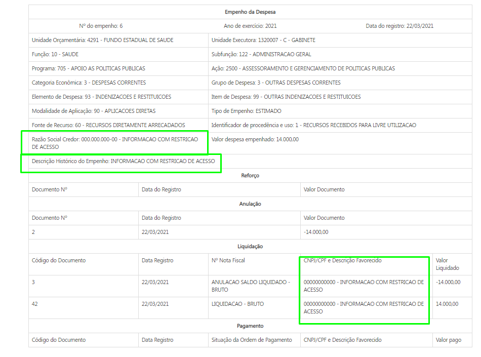

No **banco de dados** do Portal da Transparência as informações de nome, CPF e histórico de empenho devem ser armazenadas sem anonimização, permitindo filtros que utilizem essas informações. Destaca-se ainda que a funcionalidade deve permitir que os dados deixem de ser anonimizados a qualquer momento sob demanda da CGE.

## Consulta Despesa / Restos a Pagar

A anonimização deve ser aplicada:

- Gráficos e tabelas do nível favorecido
- Formulários de detalhamento de documentos
- Pesquisa avançada;
- Imprimir página;
- Exportar para csv;
- Exportar para pdf.

### Exemplo 1

Anonimizar os dados dos credores de indenização referente aos filhos de hansênicos.

Combinação a ser utilizada: - Ano de exercício (2021) - Unidade orçamentária (4291- Fundo Estadual de Saúde) - Unidade Executora (1320007 - C- Gabinete) - Número dos Empenhos (6 a 38 )

#### Gráficos e tabelas do nível favorecido

[output not shown]

**Despesa**

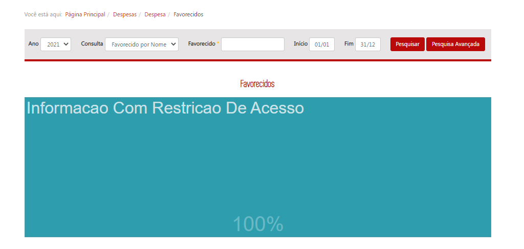

**Despesa**

[figure not shown]

#### Formulários de detalhamento de documentos

Ao acessar os formulários de detalhamento os seguintes campos devem ser anonimizados:

- Campo *Razão Social do Credor* do formulário de empenho da despesa:
- Campo *CNPJ/CPF e Descrição do Favorecido* do formulário de liquidação e pagamento:

**Despesa**

CORRIGIDO

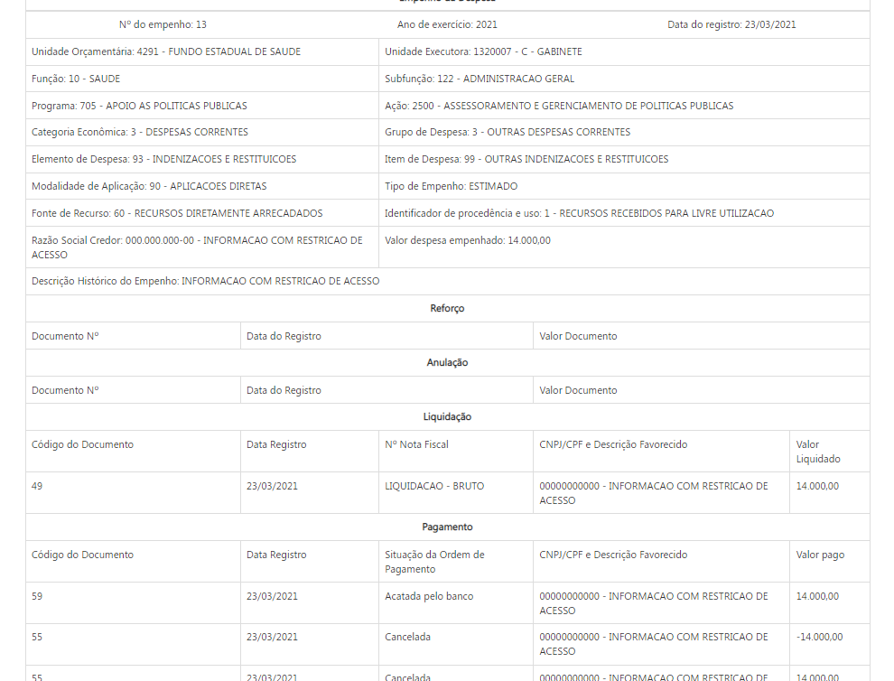

### Exemplo 2

Anonimizar o **histórico de empenho** dos credores de prêmios lotéricos.

Combinação a ser utilizada: - Ano de exercício (Todos) - Unidade orçamentária (2041- Loteria do Estado de Minas Gerais) - Elemento Item de Despesa - (3102 - Prêmios Lotéricos)

#### Formulários de detalhamento de documentos

Ao acessar os formulários de detalhamento os seguintes campos devem ser anonimizados:

- Campo *Razão Social do Credor* do formulário de empenho da despesa:

**Despesa**

A funcionalidade não foi aplicada no histórico de empenho da combinação do exemplo 2 - CORRIGIDO http://homologa3.prodemge.gov.br/age7/despesa-estado/despesa/despesa-orgaos/2020/01-01-2020/31-12-2020/9770/4514/588/25/51/2933918/1/3455/empenhado/71/6809941/0/0

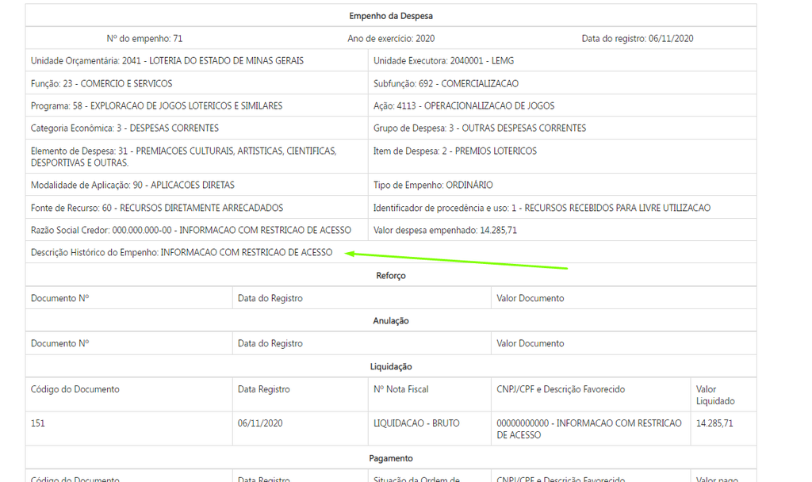

#### Pesquisa Avançada

A anonimização deve ocorrer quando o usuário marcar o campo *exibir favorecidos*.

**Despesa**

Não foi possível verificar a funcionalidade na pesquisa avançada porque ela não está respondendo aos filtros selecionados.- **CORRIGIDO**

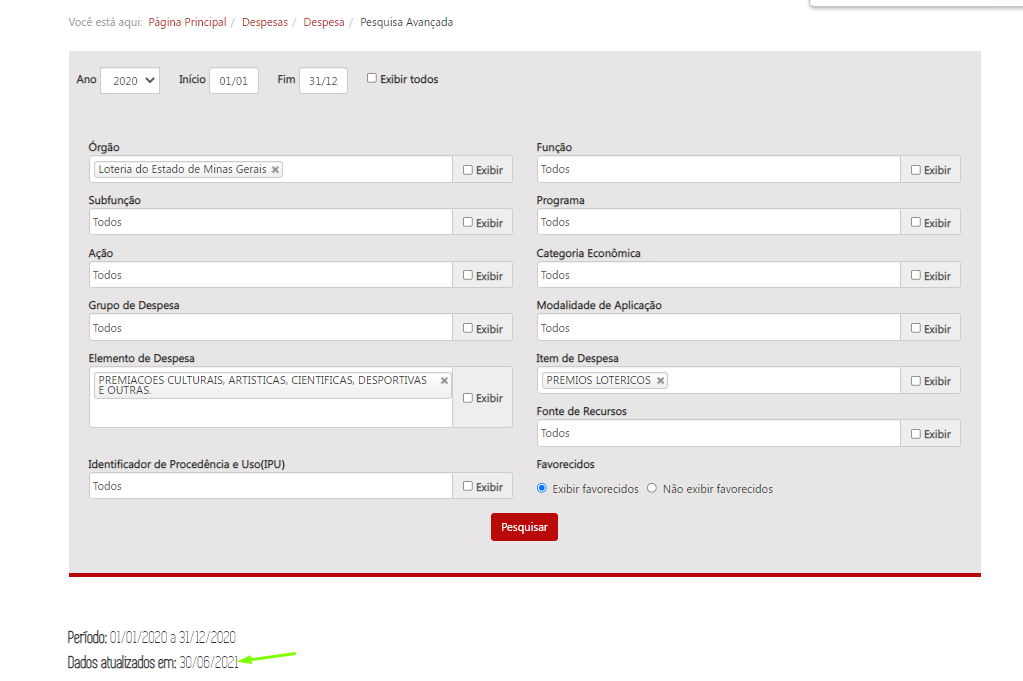

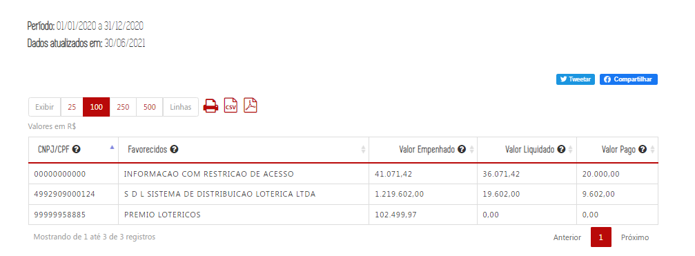

## **TESTES**

Favor implementar as combinações abaixo para testes. A CGE irá verificar os dados e depois elas serão retiradas para nova conferência.

A anonimização realizada na consulta de despesa deve ser refletida na consulta de Restos a Pagar quando o empenho for inscrito em RP processado ou RP não processado.

**TESTE 1**

Combinação a ser utilizada:

- Ano de exercício (2016)
- Unidade orçamentária (4291- Fundo Estadual de Saúde)
- Unidade Executora (1320003 - C - SUBSILS/SGP(RH)
- UPG (550 - DESPESAS ADMINISTRATIVAS DA SUPERINTENCIA DE GESTAO DE PESSOAS)

OBS: Os empenhos foram realizados em 2016 (eg.[Consulta de Despesa](http://www.transparencia.mg.gov.br/despesa-estado/despesa/despesa-favorecidos/2016/01-01-2016/31-12-2016/1741243/ADRIANA%20MARQUES%20DE%20ARAUJO/0/3/0/466/20/42/2991/130/18/3541/empenhado/4/9914927/0/0)), porém estão inscritos em Restos a Pagar em 2021 (eg. [Consulta Restos a Pagar](http://www.transparencia.mg.gov.br/despesa-estado/restos-a-pagar/restospagar-orgaos/2021/4113/466/42/20/2991/130/18))

**Despesa - Pesquisa Básica**

Anonimização realizada em 2016 - **CONFERE**

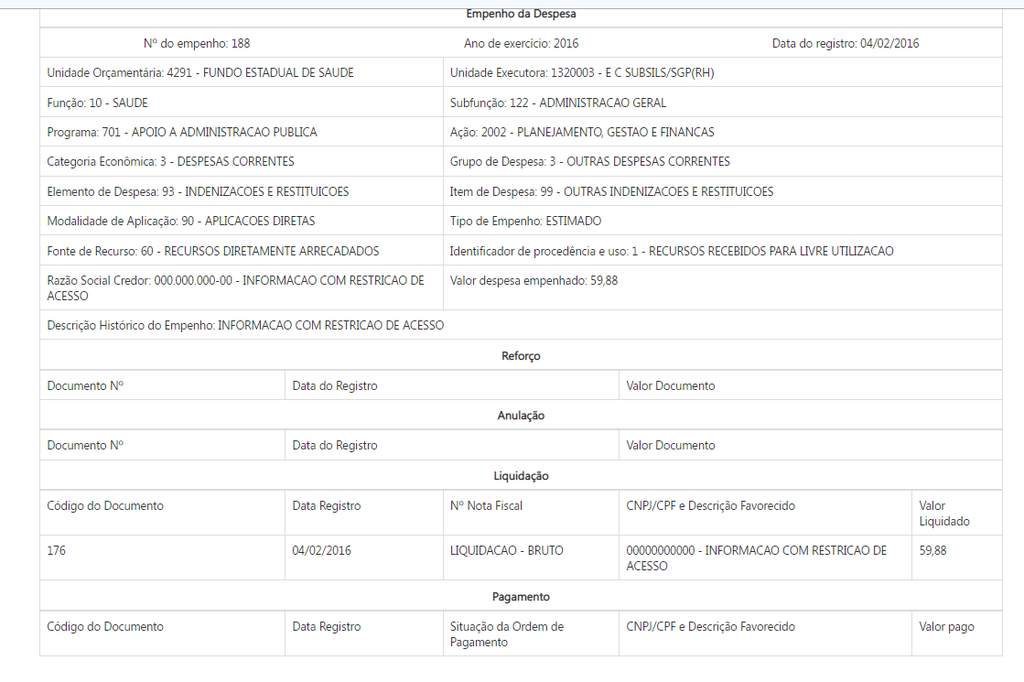

**Restos a Pagar - Pesquisa Básica**

**Corrigido**

[Link Produção](https://www.transparencia.mg.gov.br/despesa-estado/despesa/despesa-orgaos/2016/01-01-2016/31-12-2016/3541/1788/466/20/42/1741243/0/2991/empenhado/4/9914927/0/0)

[Link homologação](http://homologa3.prodemge.gov.br/age7/despesa-estado/restos-a-pagar/restospagar-orgaos/2021/9905/562/51/25/3566/154/483/5545995)

[figure not shown]

**TESTE 2**

- Ano de exercício (2020)
- Unidade orçamentária (2011 - INSTITUTO DE PREVIDENCIA DOS SERVIDORES DO ESTADO DE MINAS GERAIS)
- Item de Despesa: (7 - PRECATORIOS - OUTROS)
- Identificador de procedência e uso: 9 - RECURSOS RECEBIDOS PARA PRECATORIOS E SENTENCAS JUDICIAIS

OBS: Os empenhos foram realizados em 2020 (eg.[Consulta de Despesa - Pesquisa Avançada](http://www.transparencia.mg.gov.br/despesa-estado/despesa/despesa-resultado-pesquisa-avancada/2020/01-01-2020/31-12-2020/3976/0/0/0/0/0/0/0/0/2767/0/97/0/0/0/0/0/0/0/0/0/0/0/0/1/0)) e [Pesquisa Básica](http://www.transparencia.mg.gov.br/despesa-estado/despesa/despesa-orgaos/2020/01-01-2020/31-12-2020/3976/1894/476/20/39), porém estão inscritos em Restos a Pagar em 2021 (eg. [Consulta Restos a Pagar - Pesquisa Avançada](http://www.transparencia.mg.gov.br/despesa-estado/restos-a-pagar/restospagar-resultado-pesquisa-avancada/2021/4193/0/0/0/0/0/0/0/0/2767/0/97/0/0/0/0/0/0/0/0/0/0/0/0/1/0/0)) e [Pesquisa Básica](http://www.transparencia.mg.gov.br/despesa-estado/restos-a-pagar/restospagar-orgaos/2021/4193/476/39/20/2767/130/58)

**Despesa - Pesquisa Básica**

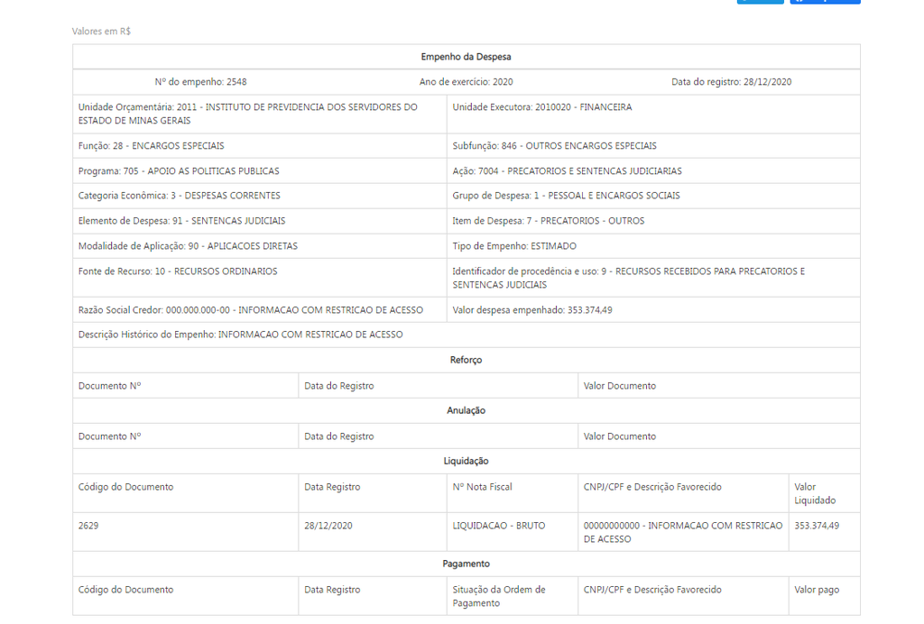

Despesa - Pesquisa avançada

[figure not shown]

**Restos a Pagar - Pesquisa Básica**

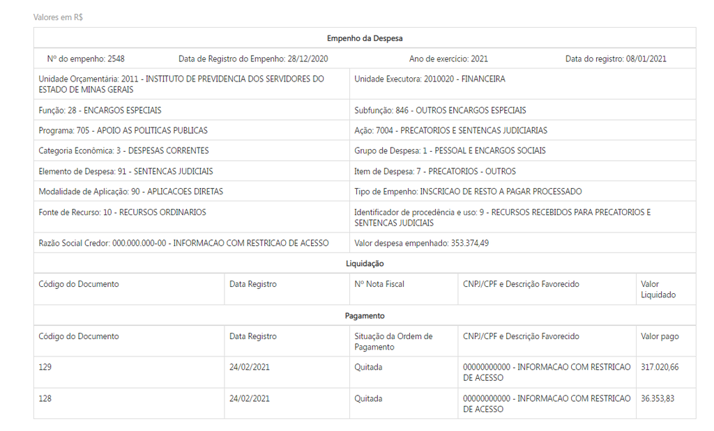